# Take Home Exercise 4

Visualising and Analysing Daily Routines

JUNQIU NI (MITB)  
2022-05-22

# 1. Overview

In this take home exercise, I will reveal the daily routines of two selected participants of the city of Engagement, Ohio USA using **ViSIElse**.

# 2. Getting Started

# 2.1 Loading R packages

Before we get started, it is important to ensure that the R packages have been installed. If yes, we will load the R packages. If they have yet to be installed, we will install the R packages and load them onto R environment.

The chunk code below will do the trick.

```r
packages = c('tidyverse','knitr','ggdist', 'ggridges',
             'ggthemes', 'hrbrthemes',
             'ggrepel', 'ggforce','viridis','zoo','chron','lubridate','ViSiElse')

for(p in packages){
  if(!require(p, character.only = T)){
    install.packages(p)
  }
  library(p, character.only = T)
}
```

# 2.2. Importing Data

```r
travel_data <- read_csv("data/TravelJournal.csv") %>%
  mutate(date = as.Date(travelStartTime))
```

# 2.2. Date Preprocessing

We choose two participants whose participantId is 23 and 188 and see the daily patterns of them. To observe the daily patterns, I change each start time and end time of the travel by using minute.

```r
person1 <- travel_data %>% filter(participantId==23)
person1$starttime <- 60*hour(person1$travelStartTime)+minute(person1$travelStartTime)
person1$endtime <- 60*hour(person1$travelEndTime)+minute(person1$travelEndTime)
person2 <- travel_data %>% filter(participantId==188)
person2$starttime <- 60*hour(person2$travelStartTime)+minute(person2$travelStartTime)
person2$endtime <- 60*hour(person2$travelEndTime)+minute(person2$travelEndTime)
```

```r
routine1<-person1[, c('purpose','date','starttime','endtime')]
routine2<-person2[, c('purpose','date','starttime','endtime')]
```

```r
routine1 <- routine1 %>%
  mutate(end = purpose)

routine1$purpose<-sub("^","start",routine1$purpose)
routine1$end<-sub("^","end",routine1$end)

routine2 <- routine2 %>%
  mutate(end = purpose)

routine2$purpose<-sub("^","start",routine2$purpose)
routine2$end<-sub("^","end",routine2$end)
```

I use [`pivot_wider`](https://tidyr.tidyverse.org/reference/pivot_wider.html) to pivot the original data and display the time in minute with corresponding event.

```r
routine1 <- routine1 %>%
  group_by(purpose) %>%
  mutate(row = row_number()) %>%
  tidyr::pivot_wider(names_from = purpose, values_from = starttime) %>%
  tidyr::pivot_wider(names_from = end, values_from = endtime) %>%
  select(-row)
```

```r
routine2 <- routine2 %>%
  group_by(purpose) %>%
  mutate(row = row_number()) %>%
  tidyr::pivot_wider(names_from = purpose, values_from = starttime) %>%
  tidyr::pivot_wider(names_from = end, values_from = endtime) %>%
  select(-row)
```

# 3. ViSIEIse to observe the daily patterns

Then we display the daily patterns of these two participants using **visielse()**.

```r
v1 <- visielse(routine1)
```

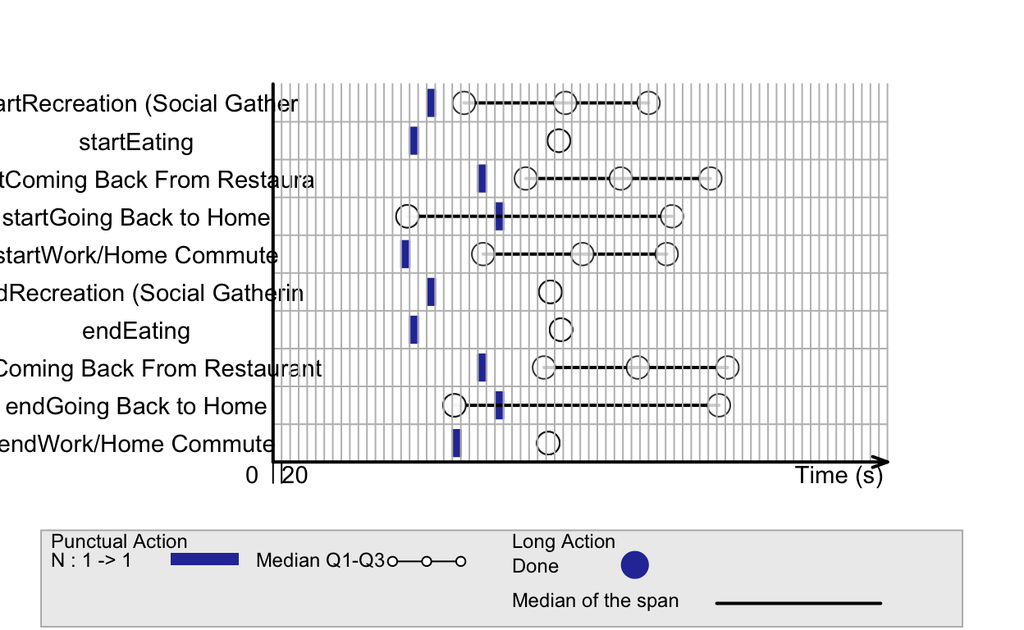

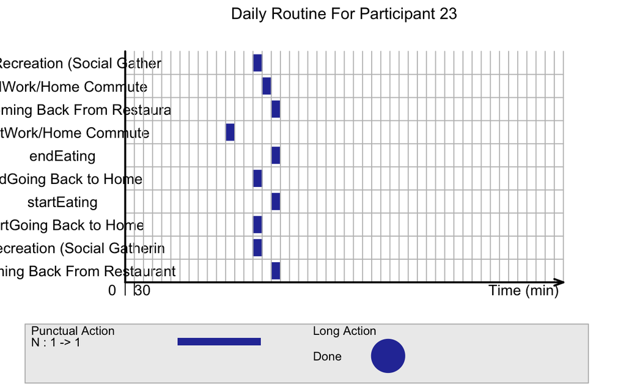

```r
b1 <-ConvertFromViSibook(v1@book)
b1 <- b1[order(as.numeric(b1$showorder)), ]
b1$showorder <- c(1,7,3,8,4,9,5,10,6,2)
b1 <- b1[order(as.numeric(b1$showorder)), ]

v1 <- visielse(routine1,book = b1, informer = NULL, doplot = F, pixel = 30)
plot(v1, vp0w = 0.7, unit.tps = "min", scal.unit.tps = 30, main = "Daily Routine For Participant 23")
```

```r
v2 <- visielse(routine2)
```

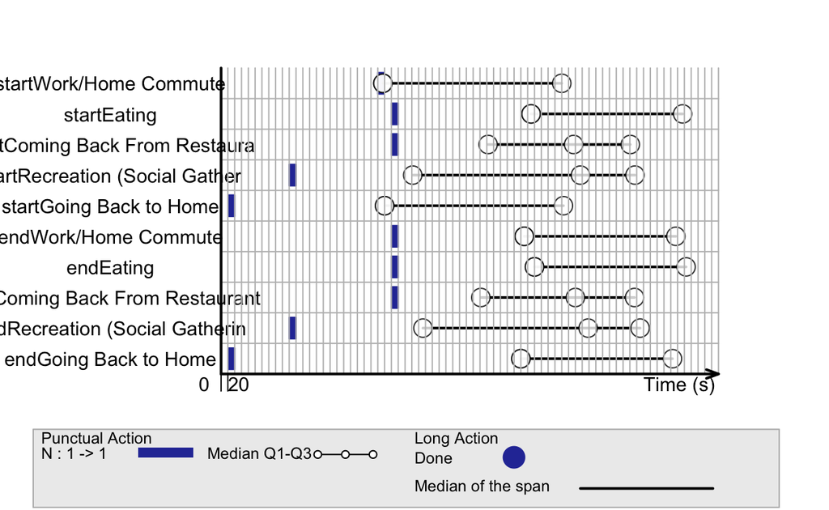

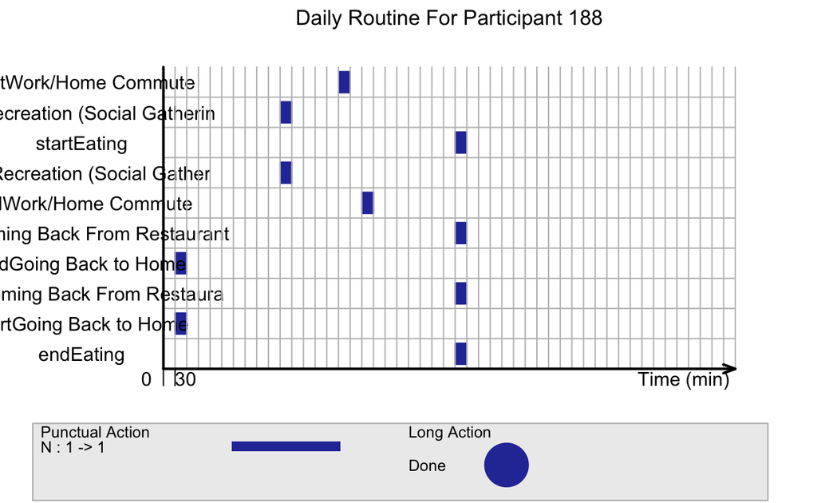

```r
b2 <-ConvertFromViSibook(v2@book)
b2 <- b2[order(as.numeric(b1$showorder)), ]
b2$showorder <- c(1,7,3,8,4,9,5,10,6,2)
b2 <- b2[order(as.numeric(b1$showorder)), ]

v2 <- visielse(routine2,book = b2, informer = NULL, doplot = F, pixel = 30)
plot(v2, vp0w = 0.7, unit.tps = "min", scal.unit.tps = 30, main = "Daily Routine For Participant 188")
```